# Análise de Componentes Principais (ACP) — **Resolução**

11 dezembro 2025

> Pacotes usados: `ISLR2`, `mlbench`, `pls`, `ggplot2`, `dplyr`, `tibble`.

```r
# Instale se necessário: install.packages(c("ISLR2","mlbench","pls","ggplot2","dplyr"))
library(ISLR2)
library(mlbench)
library(pls)
library(ggplot2)
library(dplyr)
library(tibble)
```

# Exercício 1 — NCI60 (expressão génica; p ≈ 6.830)

**Dados**: `ISLR2::NCI60` (64 linhas; ~6.830 genes).

## (1) Dimensão e valores em falta

```r
# Obter matriz de expressão
X_raw <- NCI60$data
labs   <- NCI60$labs
n <- nrow(X_raw); p <- ncol(X_raw)
# Contagem de NA
na_total <- sum(is.na(X_raw))
list(n_observacoes = n, p_variaveis = p, faltantes_total = na_total)
```

```
## $n_observacoes
## [1] 64
##
## $p_variaveis
## [1] 6830
##
## $faltantes_total
## [1] 0
```

**Comentário.** `p` é grande face a `n`; não há (tipicamente) valores em falta no objeto original.

## (2) Padronização e justificação

```r
X <- scale(X_raw)  # centrar e padronizar por gene
# Confirmar centragem/padronização
summ <- as_tibble(X) |>
  summarise(across(everything(), list(media = ~mean(.x), sd = ~sd(.x))))
# Mostrar apenas primeiras 6 colunas (para inspeção)
round(as.matrix(summ)[,1:12], 3)
```

```
## 1_media    1_sd 2_media    2_sd 3_media    3_sd 4_media    4_sd 5_media    5_sd
##       0       1       0       1       0       1       0       1       0       1
## 6_media    6_sd
##       0       1
```

**Porquê correlações (padronizar)**: variâncias dos genes diferem muito em escala; sem padronização, CP1 seria dominada pelos genes de maior variância. Usar a matriz de **correlações** (equivalente a padronizar e fazer PCA na matriz centrada) dá a cada gene o mesmo peso inicial.

## (3) PCA: valores proprios, PVE e plots

```r
pc_nci <- prcomp(X, center = FALSE, scale. = FALSE)
# Autovalores (variâncias dos scores)
summary(pc_nci)
```

```
## Importance of components:
##                            PC1      PC2      PC3      PC4      PC5      PC6
## Standard deviation     27.8535 21.48136 19.82046 17.03256 15.97181 15.72108
## Proportion of Variance  0.1136  0.06756  0.05752  0.04248  0.03735  0.03619
## Cumulative Proportion   0.1136  0.18115  0.23867  0.28115  0.31850  0.35468
##                             PC7      PC8      PC9     PC10     PC11     PC12
## Standard deviation     14.47145 13.54427 13.14400 12.73860 12.68672 12.15769
## Proportion of Variance  0.03066  0.02686  0.02529  0.02376  0.02357  0.02164
## Cumulative Proportion   0.38534  0.41220  0.43750  0.46126  0.48482  0.50646
##                            PC13     PC14     PC15     PC16     PC17     PC18
## Standard deviation     11.83019 11.62554 11.43779 11.00051 10.65666 10.48880
## Proportion of Variance  0.02049  0.01979  0.01915  0.01772  0.01663  0.01611
## Cumulative Proportion   0.52695  0.54674  0.56590  0.58361  0.60024  0.61635
##                            PC19    PC20     PC21    PC22    PC23    PC24
## Standard deviation     10.43518 10.3219 10.14608 10.0544 9.90265 9.64766
## Proportion of Variance  0.01594  0.0156  0.01507  0.0148 0.01436 0.01363
## Cumulative Proportion   0.63229  0.6479  0.66296  0.6778 0.69212 0.70575
##                           PC25    PC26    PC27   PC28    PC29    PC30    PC31
## Standard deviation     9.50764 9.33253 9.27320 9.0900 8.98117 8.75003 8.59962
## Proportion of Variance 0.01324 0.01275 0.01259 0.0121 0.01181 0.01121 0.01083
## Cumulative Proportion  0.71899 0.73174 0.74433 0.7564 0.76824 0.77945 0.79027
##                           PC32    PC33    PC34    PC35    PC36    PC37    PC38
## Standard deviation     8.44738 8.37305 8.21579 8.15731 7.97465 7.90446 7.82127
## Proportion of Variance 0.01045 0.01026 0.00988 0.00974 0.00931 0.00915 0.00896
## Cumulative Proportion  0.80072 0.81099 0.82087 0.83061 0.83992 0.84907 0.85803
##                           PC39    PC40    PC41   PC42    PC43   PC44    PC45
## Standard deviation     7.72156 7.58603 7.45619 7.3444 7.10449 7.0131 6.95839
## Proportion of Variance 0.00873 0.00843 0.00814 0.0079 0.00739 0.0072 0.00709
## Cumulative Proportion  0.86676 0.87518 0.88332 0.8912 0.89861 0.9058 0.91290
##                          PC46    PC47    PC48    PC49    PC50    PC51    PC52
## Standard deviation     6.8663 6.80744 6.64763 6.61607 6.40793 6.21984 6.20326
## Proportion of Variance 0.0069 0.00678 0.00647 0.00641 0.00601 0.00566 0.00563
## Cumulative Proportion  0.9198 0.92659 0.93306 0.93947 0.94548 0.95114 0.95678
##                           PC53    PC54    PC55    PC56    PC57   PC58    PC59
## Standard deviation     6.06706 5.91805 5.91233 5.73539 5.47261 5.2921 5.02117
## Proportion of Variance 0.00539 0.00513 0.00512 0.00482 0.00438 0.0041 0.00369
## Cumulative Proportion  0.96216 0.96729 0.97241 0.97723 0.98161 0.9857 0.98940
##                           PC60    PC61    PC62    PC63      PC64
## Standard deviation     4.68398 4.17567 4.08212 4.04124 2.037e-14
## Proportion of Variance 0.00321 0.00255 0.00244 0.00239 0.000e+00
## Cumulative Proportion  0.99262 0.99517 0.99761 1.00000 1.000e+00
```

```r
ev  <- pc_nci$sdev^2
pve <- ev / sum(ev)
cpve <- cumsum(pve)
# Tabela com as 15 primeiras CPs
resumo_pve <- tibble(
  CP = seq_along(ev),
  autovalor = ev,
  PVE = pve,
  PVE_acumulada = cpve
) |>
  slice(1:15)
resumo_pve
```

```
## # A tibble: 15 × 4
##       CP autovalor    PVE PVE_acumulada
##    <int>     <dbl>  <dbl>         <dbl>
##  1     1      776. 0.114          0.114
##  2     2      461. 0.0676         0.181
##  3     3      393. 0.0575         0.239
##  4     4      290. 0.0425         0.281
##  5     5      255. 0.0373         0.318
##  6     6      247. 0.0362         0.355
##  7     7      209. 0.0307         0.385
##  8     8      183. 0.0269         0.412
##  9     9      173. 0.0253         0.437
## 10    10      162. 0.0238         0.461
## 11    11      161. 0.0236         0.485
## 12    12      148. 0.0216         0.506
## 13    13      140. 0.0205         0.527
## 14    14      135. 0.0198         0.547
## 15    15      131. 0.0192         0.566
```

**Scree plot** e **PVE acumulada**:

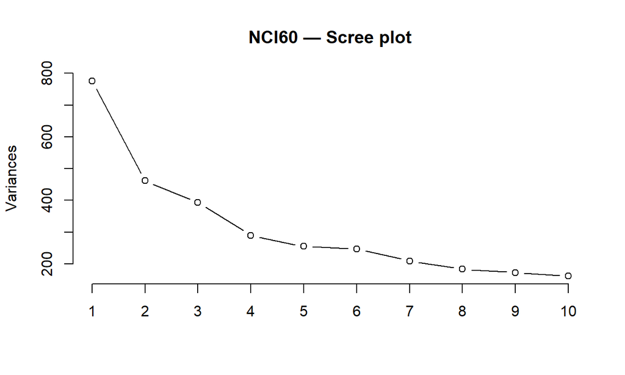

```r
# Scree
screeplot(pc_nci, type = "lines", main = "NCI60 — Scree plot")
```

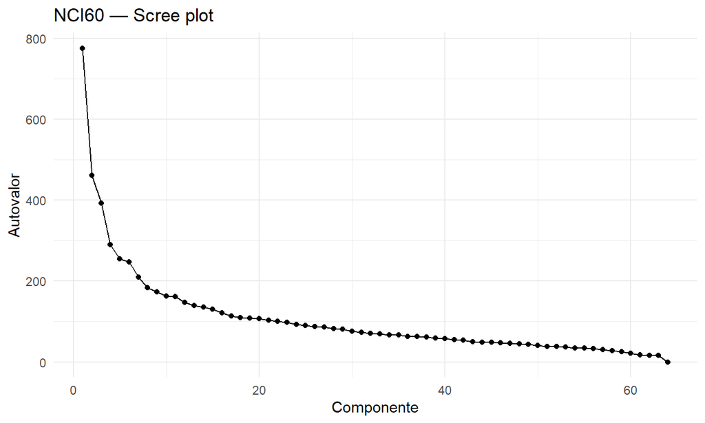

```r
qplot(y = ev, x = seq_along(ev), geom = c("line","point")) +
  labs(x = "Componente", y = "Autovalor", title = "NCI60 — Scree plot") +
  theme_minimal()
```

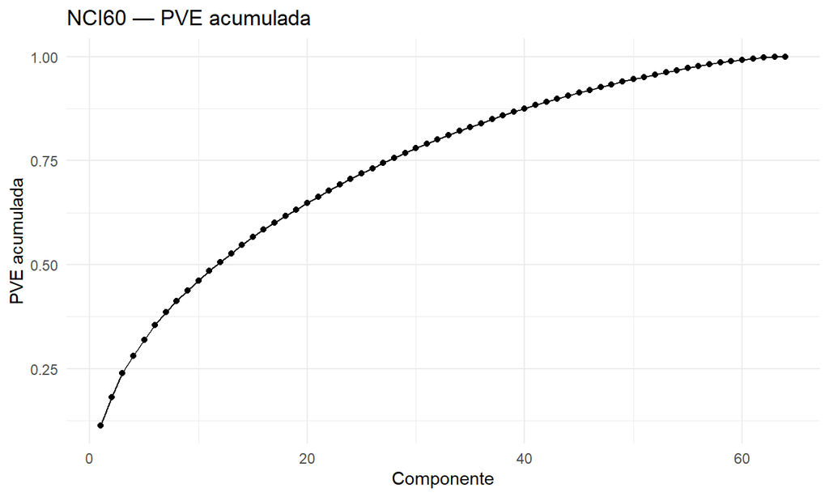

```r
# PVE acumulada
qplot(y = cpve, x = seq_along(cpve), geom = c("line","point")) +
  labs(x = "Componente", y = "PVE acumulada", title = "NCI60 — PVE acumulada") +
  theme_minimal()
```

## (4) Scores CP1 vs CP2 com cores por tipo de cancro

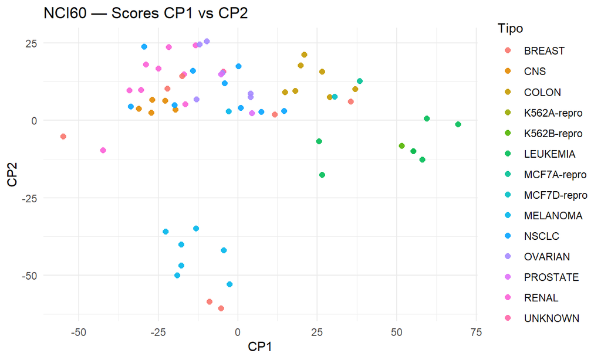

```r
Scores <- as_tibble(pc_nci$x[,1:2], .name_repair = "minimal") |>
  mutate(tipo = labs)
colnames(Scores)[1:2] <- c("CP1","CP2")
# Ordenar níveis para legenda estável
Scores$tipo <- factor(Scores$tipo)

ggplot(Scores, aes(CP1, CP2, color = tipo)) +
  geom_point(size = 2, alpha = 0.9) +
  labs(title = "NCI60 — Scores CP1 vs CP2", color = "Tipo") +
  theme_minimal() +
  theme(legend.position = "right")
```

**Comentário.** Observa‑se frequentemente agrupamento parcial por tipo (e.g., leucemias vs melanomas), evidenciando estrutura biológica nas primeiras CPs.

## (5) Top 25 genes por |loading| em CP1 e CP2

```r
load <- pc_nci$rotation  # loadings (p x p)
ord1 <- order(abs(load[,1]), decreasing = TRUE)[1:25]
ord2 <- order(abs(load[,2]), decreasing = TRUE)[1:25]
Top_CP1 <- tibble(gene = colnames(X_raw)[ord1], loading = load[ord1,1])
Top_CP2 <- tibble(gene = colnames(X_raw)[ord2], loading = load[ord2,2])
list(Top25_CP1 = Top_CP1, Top25_CP2 = Top_CP2,
     sobreposicao = length(intersect(Top_CP1$gene, Top_CP2$gene)))
```

```
## $Top25_CP1
## # A tibble: 25 × 2
##    gene  loading
##    <chr>   <dbl>
##  1 5951  -0.0311
##  2 5874  -0.0304
##  3 5886  -0.0300
##  4 5872  -0.0296
##  5 5937  -0.0294
##  6 5868  -0.0292
##  7 5887  -0.0292
##  8 5960  -0.0290
##  9 5956  -0.0289
## 10 5902  -0.0286
## # ℹ 15 more rows
##
## $Top25_CP2
## # A tibble: 25 × 2
##    gene  loading
##    <chr>   <dbl>
##  1 4320  -0.0406
##  2 4321  -0.0396
##  3 4327  -0.0387
##  4 4324  -0.0378
##  5 4193  -0.0370
##  6 4322  -0.0368
##  7 4325  -0.0367
##  8 4335  -0.0363
##  9 4329  -0.0360
## 10 4192  -0.0359
## # ℹ 15 more rows
##
## $sobreposicao
## [1] 0
```

**Discussão.** Normalmente há pouca sobreposição: CPs ortogonais capturam eixos distintos de variação; genes dominantes em CP1 tendem a não repetir em CP2.

# Exercício 2 — Sonar (sinais; p = 60)

## (1) Preparação

```r
data(Sonar)
X_sonar <- scale(as.matrix(Sonar[,1:60]))
y_sonar <- Sonar$Class
c(dim(X_sonar), classes = levels(y_sonar))
```

```
##                   classes1 classes2
##    "208"     "60"      "M"      "R"
```

## (2) PCA, PVE e scree plot

```r
pc_sonar <- prcomp(X_sonar, center = FALSE)
ev2  <- pc_sonar$sdev^2
pve2 <- ev2 / sum(ev2)
cpve2 <- cumsum(pve2)
head(tibble(CP = 1:10, PVE = pve2[1:10], PVE_acum = cpve2[1:10]))
```

```
## # A tibble: 6 × 3
##      CP    PVE PVE_acum
##   <int>  <dbl>    <dbl>
## 1     1 0.203     0.203
## 2     2 0.189     0.392
## 3     3 0.0855    0.478
## 4     4 0.0568    0.535
## 5     5 0.0501    0.585
## 6     6 0.0406    0.625
```

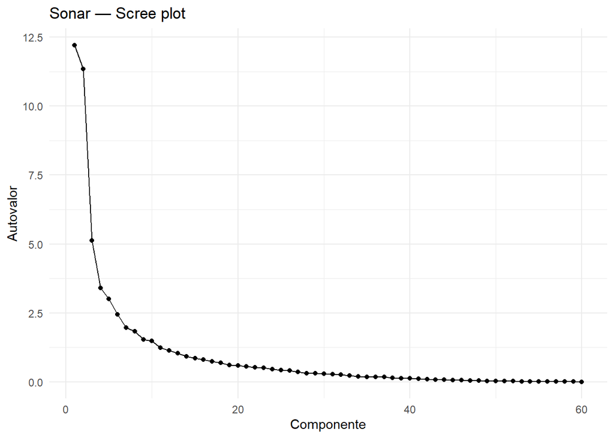

```r
# Scree plot
qplot(y = ev2, x = seq_along(ev2), geom = c("line","point")) +
  labs(x = "Componente", y = "Autovalor", title = "Sonar — Scree plot") +
  theme_minimal()
```

## (3) CP1 vs CP2 colorido por classe (M/R)

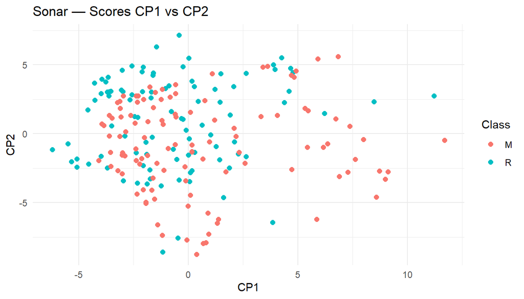

```r
sc2 <- as_tibble(pc_sonar$x[,1:2]) |>
  mutate(Class = y_sonar)
colnames(sc2)[1:2] <- c("CP1","CP2")

ggplot(sc2, aes(CP1, CP2, color = Class)) +
  geom_point(size = 2) +
  labs(title = "Sonar — Scores CP1 vs CP2") +
  theme_minimal()
```

**Comentário.** A separação raramente é perfeita, mas costuma haver tendência de distinção parcial entre M e R nas primeiras CPs.

## (4) Biplot e top‑5 variáveis por |loading|

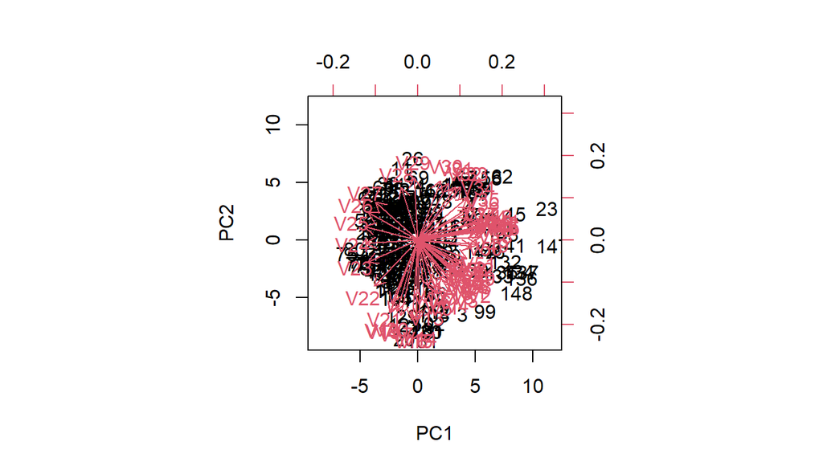

```r
# Biplot base (pode ficar visualmente carregado)
biplot(pc_sonar, scale = 0)
```

```r
# Top-5 por |loading| em CP1 e CP2
load2 <- pc_sonar$rotation
Top5_CP1 <- tibble(var = colnames(Sonar)[1:60][order(abs(load2[,1]), decreasing = TRUE)[1:5]],
                   loading = load2[order(abs(load2[,1]), decreasing = TRUE)[1:5],1])
Top5_CP2 <- tibble(var = colnames(Sonar)[1:60][order(abs(load2[,2]), decreasing = TRUE)[1:5]],
                   loading = load2[order(abs(load2[,2]), decreasing = TRUE)[1:5],2])
list(Top5_CP1 = Top5_CP1, Top5_CP2 = Top5_CP2)
```

```
## $Top5_CP1
## # A tibble: 5 × 2
##   var   loading
##   <chr>   <dbl>
## 1 V41     0.202
## 2 V45     0.201
## 3 V46     0.199
## 4 V42     0.198
## 5 V39     0.189
##
## $Top5_CP2
## # A tibble: 5 × 2
##   var   loading
##   <chr>   <dbl>
## 1 V16    -0.238
## 2 V15    -0.238
## 3 V14    -0.232
## 4 V17    -0.222
## 5 V19    -0.217
```

# Exercício 3 — Espectroscopia NIR (*yarn*; p ≈ 268)

## (1) Carregar e construir matriz de espectros

```r
X_yarn <- scale(yarn$NIR)  # apenas espectros; padronizar por coluna
dim(X_yarn)
```

```
## [1]  28 268
```

## (2) PCA, valores proprios, PVE e gráficos

```r
pc_yarn <- prcomp(X_yarn, center = FALSE)
ev3  <- pc_yarn$sdev^2
pve3 <- ev3 / sum(ev3)
cpve3 <- cumsum(pve3)
head(tibble(CP = 1:10, PVE = round(pve3[1:10], 4), PVE_acum = round(cpve3[1:10],4)))
```

```
## # A tibble: 6 × 3
##      CP    PVE PVE_acum
##   <int>  <dbl>    <dbl>
## 1     1 0.511     0.511
## 2     2 0.309     0.82
## 3     3 0.165     0.985
## 4     4 0.0099    0.995
## 5     5 0.0022    0.997
## 6     6 0.0013    0.998
```

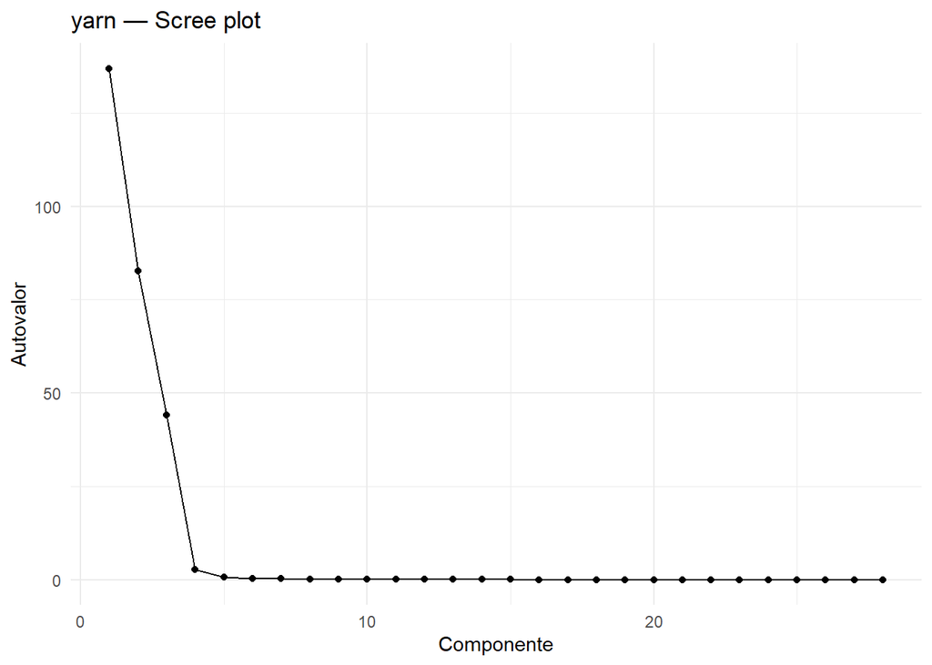

```r
# Scree plot
qplot(y = ev3, x = seq_along(ev3), geom = c("line","point")) +
  labs(x = "Componente", y = "Autovalor", title = "yarn — Scree plot") +
  theme_minimal()
```

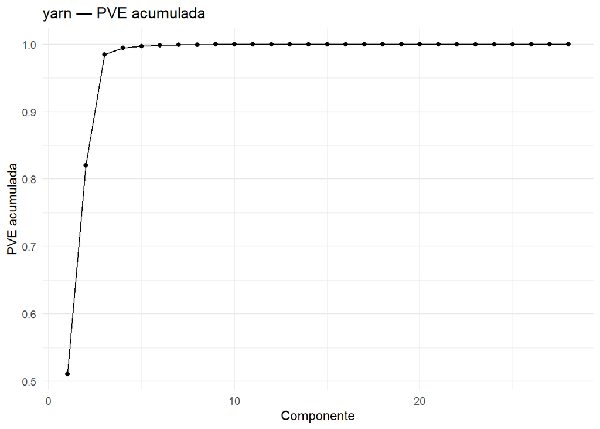

```r
# PVE acumulada
qplot(y = cpve3, x = seq_along(cpve3), geom = c("line","point")) +
  labs(x = "Componente", y = "PVE acumulada", title = "yarn — PVE acumulada") +
  theme_minimal()
```

## (3) Scores plots (CP1 vs CP2 e CP2 vs CP3)

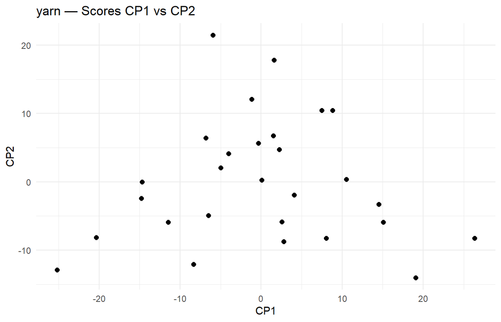

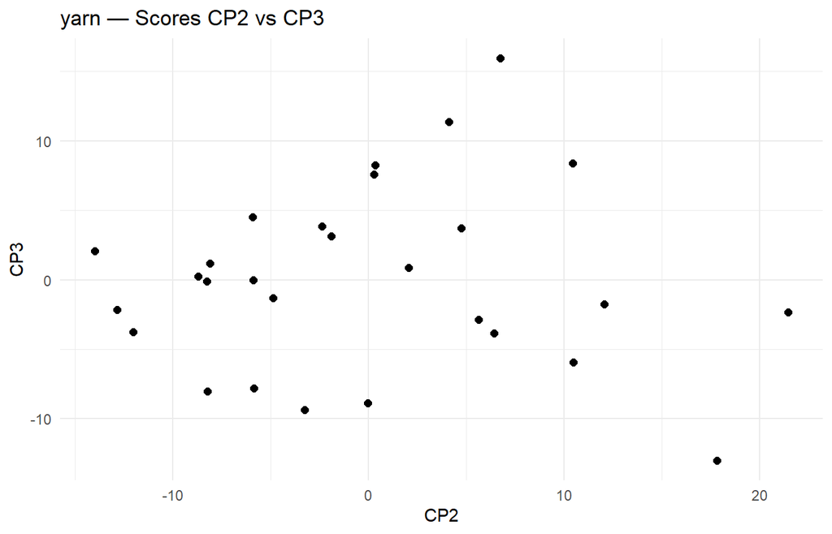

```r
sc3 <- as_tibble(pc_yarn$x[,1:3])
colnames(sc3) <- c("CP1","CP2","CP3")

p1 <- ggplot(sc3, aes(CP1, CP2)) + geom_point(size = 2) + theme_minimal() +
  labs(title = "yarn — Scores CP1 vs CP2")
p2 <- ggplot(sc3, aes(CP2, CP3)) + geom_point(size = 2) + theme_minimal() +
  labs(title = "yarn — Scores CP2 vs CP3")
print(p1); print(p2)
```

**Comentário.** Em espectros, CP1 e CP2 tendem a capturar variações largas de base e bandas específicas; padrões de lote podem emergir.

## (4) Bandas com maior contribuição (|loadings|) em CP1 e CP2

```r
load3 <- pc_yarn$rotation
idx1 <- order(abs(load3[,1]), decreasing = TRUE)[1:15]
idx2 <- order(abs(load3[,2]), decreasing = TRUE)[1:15]
TopBand_CP1 <- tibble(indice_onda = idx1, loading = load3[idx1,1])
TopBand_CP2 <- tibble(indice_onda = idx2, loading = load3[idx2,2])
list(TopBand_CP1 = TopBand_CP1, TopBand_CP2 = TopBand_CP2,
     sobreposicao = length(intersect(idx1, idx2)))
```

```
## $TopBand_CP1
## # A tibble: 15 × 2
##    indice_onda loading
##          <int>   <dbl>
##  1          71 -0.0842
##  2          72 -0.0835
##  3          70 -0.0834
##  4         146 -0.0833
##  5         145 -0.0833
##  6          52  0.0832
##  7          73 -0.0830
##  8         112 -0.0830
##  9         114 -0.0830
## 10         111 -0.0830
## 11         113 -0.0830
```

[output cut: 27 more lines]